01

# PyData London

May 2026

**107th Meetup**  
Hosted by Man Group

@pydatalondon.bsky.social

Community

## PyData Code of Conduct

> "Be thoughtful.  
> Be kind to each other."

pydata.org/code-of-conduct

[interactive chart not shown]

03

## NumFOCUS

- US-based charity supporting open-source scientific computing
- Financial and administrative support for open-source projects
- Support for many community events worldwide

numfocus.org

### NumFOCUS Sponsored Projects

numfocus.org

[interactive chart not shown]

## PyData

121 Groups on Meetup

51 Countries

209k+ Members

+more Off-platform groups

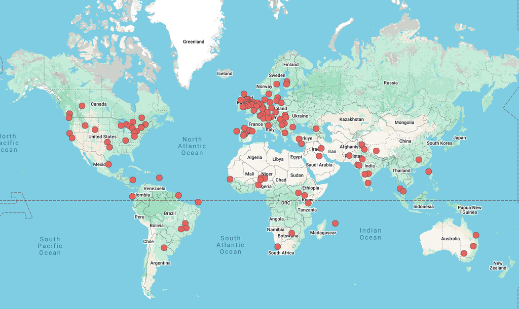

meetup.com/pro/pydata

### PyData UK Groups

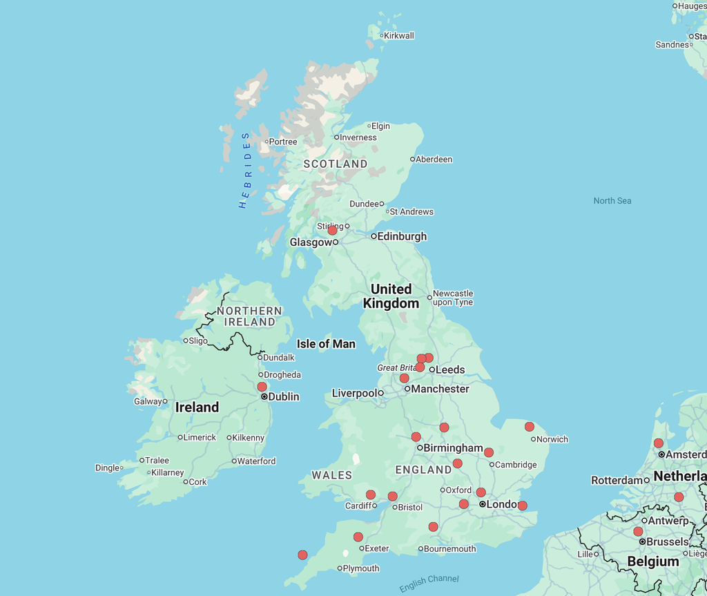

## PyData London

- 16,290 members and growing
- Monthly meetup & annual conference
- All run by volunteers

london.pydata.org/submit-a-talk

[figure not shown]

UK PyData Meetups

## May 2026

- Wed 6 May **PyData Exeter #13** — Open Source Community Talks · Innovation Hub
- Thu 7 May **PyData Cornwall #4** — Data Engineering Edition · Newquay
- Sat 16 May **PyData Organisers + Friends** — Community Tooling Hack Day · Newspeak House, London
- Fri 22 May **PyData Wolverhampton** — Python for Data Collection · Uni of Wolverhampton
- Thu 28 May **PyData Manchester** · Krakenflex, Circle Square
- Fri 29 May **PyData Bradford** · Bradford Mechanics' Institute Library

**PyData Bristol** is looking for a new sponsor / venue. **If you can help, grab John after the talks!**

Since we last met

## Python 3.14.4

shipped 7 April 2026

Bugfix-only maintenance release — but a useful nudge that **3.14 is the first version with free-threaded (no-GIL) CPython officially supported** via PEP 779. If you've been waiting to try it, now's the time.

python.org/downloads/release/python-3144

Tonight's Host & Sponsor

[figure not shown]

**Long-term sponsor**  
and partner of  
PyData London

01

World's largest publicly traded hedge fund Listed on the London Stock Exchange

02

Open roles in Tech & Research Quant researchers, engineers, data scientists & more

03

Proud sponsor of PyData London Supporting the open-source data science community

Careers man.com/careers

## Upcoming Conferences

via [pythondeadlin.es](https://pythondeadlin.es/)

[interactive chart not shown]

[figure not shown]

Annual Conference

## PyData London 2026

5 – 7 June 2026

Venue

Convene Sancroft

St. Paul's, London EC4M 7DQ

Keynotes

- Sam Colvin Pydantic Inc.
- Rachel Lee Nabors Agentic Web Leader
- Jeremiah Lowin Prefect
- Martin O'Reilly Alan Turing Institute

ti.to/pydata/pydatalondon26

No regular meetup in June — but PyData Surrey is running a satellite!

PyData London 2026 · Tickets

## Coming as a team? Save up to 15%

Group of 5+ 15% off £744.35 / ticket save ~£131 each

Book at ti.to/pydata/pydatalondon26

Coming up

## Future Meetups

June **No regular meetup** — we'll see you at the **PyData London 2026 conference**!

July+ **We're moving to a new venue** — possibly a different one in July. Keep a close eye on **Meetup.com** for details.

Got something to share?

### We're always looking for speakers.

london.pydata.org/submit-a-talk

Lightning talks (5 min) and full talks (~30 min) — beginners welcome.

## Tonight's Schedule

18:30 Doors open

19:00 Introduction You are here

19:15

Rapid deduplication and fuzzy matching of large datasets using Splink

Robin Linacre · Q&A

19:45 Break + Networking

20:00

Small Model Inference Infrastructure: Lessons Beyond vLLM

Filip Makraduli · Q&A

20:30

Build your own LLM, Live, with MicroGPT

Ian Ozsvald · Q&A

21:00 We're done → The Banker (pub)

Post-event at The Banker

Bonus slide

## Made with AI

⌨ Claude Code by Anthropic

×

✦ frontend-slides by zarazhangrui

PyData London · 107th Meetup · May 2026